# Method

In Nextflow DSL2 (v23.04.4), create two channels: "longread ch" is used for Nanopore long reads, and "shortread ch" is used for Illumina paired-end short reads. Long reads are filtered using Filtlong (v0.2.1). The parameter "--min_length 500" is used to discard reads shorter than 500 bp, and "--keep_percent 90" is used to retain the highest quality 90% of the reads, thereby removing low-quality outliers. Short reads were evaluated using FastQC (v0.11.9), and the quality distribution of long reads was visualized using NanoPlot (v1.41.0).

Assemble using the "--nano-corr" option of Flye (v2.9). Compare the short reads with the assembly draft using Bowtie2 (v2.5.1), sort the alignments using Samtools (v1.17), and polish with Pilon (v1.24) to correct the residual base-level errors. Annotate the polished assembly with Prokka (v1.14.6). Using the *alteromonas_odb12* lineage dataset, completeness was evaluated by BUSCO (v5.5.0), and accuracy and structural metrics were evaluated by QUAST (v5.2.0). The standard reference genome *Alteromonas macleodii* ATCC 27126 (GCF_000172635.2, ASM17263v2) downloaded via NCBI Datasets CLI (v14.28.1) was compared with polished and unpolished assemblies. QUAST and BUSCO metrics provide aggregated statistics.

# Results

## 1. Circos plot

[figure not shown]

```python
from IPython.display import Image, display

display(Image(filename="circos_plot.png"))
```

[output not shown]

## 2. QUAST results for the polished assembly

- Genome fraction: **98.429%**
- Duplication ratio: **1.001**
- Number of misassemblies: **19**
- Mismatches per 100 kbp: **18.33**
- Total assembly length: **4,627,920 bp**
- GC content: **44.70%**

## 4. BUSCO results

- **C:99.6% [S:99.5%, D:0.1%], F:0.0%, M:0.4%**
- 1820 Complete BUSCOs (1818 single-copy, 2 duplicated)
- 0 Fragmented BUSCOs, 8 Missing BUSCOs

These results demonstrate that the polished genome is nearly complete, with only 0.4% of expected single-copy orthologs missing. The BUSCO plot (Figure 2) visually confirms the very high proportion of complete genes.

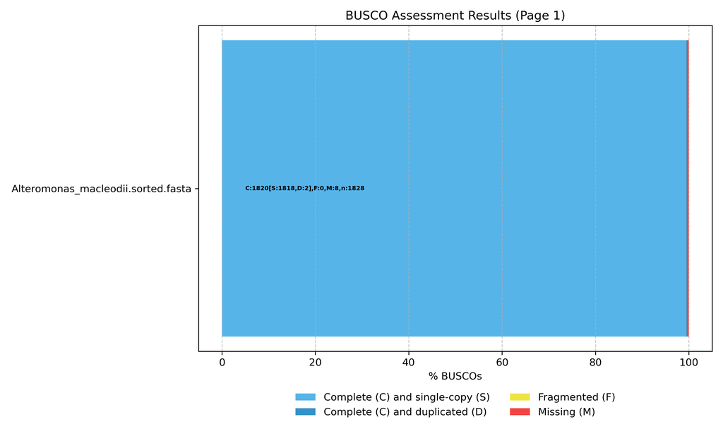

```python
from IPython.display import Image, display
display(Image(filename="busco_plot.png"))
```

**Figure 2.** BUSCO assessment results for the polished assembly.

## 5. Summary

Overall, the genome was assembled into a single 4.63 Mb contig with 99.6% BUSCO completeness, 98.4% genome fraction, and only minor base-level corrections after polishing. These results demonstrate that the assembly is both highly contiguous and nearly complete.